# Amazon.com - Employee Access Challenge

[figure not shown]

## About Dataset

The dataset for this competition (both train and test) was generated from a deep learning model trained on the [Amazon.com - Employee Access dataset](https://www.kaggle.com/c/amazon-employee-access-challenge/data). The goal is to predict **whether or not access should be granted** accroding to an employee's role information and a resource code.

There are **9 independent** variables (including id):

- **RESOURCE**: An ID for each resource.
- **MGR_ID**: The EMPLOYEE ID of the manager of the current EMPLOYEE ID record; an employee may have only one manager at a time.
- **ROLE_ROLLUP_1**: Company role grouping category id 1 (e.g. US Engineering).
- **ROLE_ROLLUP_2**: Company role grouping category id 2 (e.g. US Retail).
- **ROLE_DEPTNAME**: Company role department description (e.g. Retail).
- **ROLE_TITLE**: Company role business title description (e.g. Senior Engineering Retail Manager).
- **ROLE_FAMILY_DESC**: Company role family extended description (e.g. Retail Manager, Software Engineering).
- **ROLE_FAMILY**: Company role family description (e.g. Retail Manager).
- **ROLE_CODE**: Company role code; this code is unique to each role (e.g. Manager).

Target varibale:

- **ACTION**: ACTION is 1 if the resource was approved, 0 if the resource was not.

**Metrics**:

- AUC

## Outlines

- 1. Import Necessary Libraries
- 2. EDA & Feature Enfineering
  - 2.1. Dataset Overview
  - 2.2. Compute the Linear Relationship Between Two Features
  - 2.3. Check Consistency of Training and Test Set Distributions
  - 2.4. Generating New Feature
  - 2.5. Category Encoding
    - 2.5.1. KFold Target Encoding
    - 2.5.2. Count Encoding
- 3. Modeling
  - 3.1. Base Model
  - 3.2. Model Fine-Tuning
    - 3.2.1. RandomForestClassifier
    - 3.2.2. ExtraTreesClassifier
    - 3.2.3. LGBMClassifier
    - 3.2.4. XGBClassifier
    - 3.2.5. CatBoostClassifier
- 4. Ensemple Stacking

# 1. Import Necessary Libraries

```python
import pandas as pd
import numpy as np
from tqdm import tqdm
from itertools import combinations
import pickle
import warnings
warnings.filterwarnings("ignore")

# data visualization
import matplotlib.pyplot as plt
import seaborn as sns
import matplotlib as mpl
import matplotlib.pyplot as plt
from plotly.offline import download_plotlyjs, init_notebook_mode , plot
from plotly.graph_objs import *
init_notebook_mode()
import plotly.express as px
import plotly.figure_factory as ff
import plotly.graph_objects as go
from plotly.subplots import make_subplots
from plotly.offline import plot
import missingno as msno

# Modeling
from lightgbm import LGBMClassifier
from xgboost.sklearn import XGBClassifier
from catboost import CatBoost, CatBoostRegressor, CatBoostClassifier
from sklearn.ensemble import RandomForestClassifier , GradientBoostingClassifier , ExtraTreesClassifier
from sklearn.linear_model import LogisticRegression
from sklearn.model_selection import train_test_split
from sklearn.metrics import accuracy_score , precision_score , recall_score , f1_score , roc_auc_score
from sklearn.preprocessing import OneHotEncoder , StandardScaler
from sklearn import base
from sklearn.model_selection import KFold , StratifiedKFold , train_test_split
from category_encoders import OrdinalEncoder , LeaveOneOutEncoder
import optuna
from optuna import Trial
```

# 2. EDA

## 2.1. Dataset Overview

```
There are a total of 9 columns, and 0 features have missing values.
There are a total of 9 columns, and 0 features have missing values.
<class 'pandas.core.frame.DataFrame'>
RangeIndex: 32769 entries, 0 to 32768
Data columns (total 9 columns):
 #   Column            Non-Null Count  Dtype
---  ------            --------------  -----
 0   RESOURCE          32769 non-null  object
 1   MGR_ID            32769 non-null  object
 2   ROLE_ROLLUP_1     32769 non-null  object
 3   ROLE_ROLLUP_2     32769 non-null  object
 4   ROLE_DEPTNAME     32769 non-null  object
 5   ROLE_TITLE        32769 non-null  object
 6   ROLE_FAMILY_DESC  32769 non-null  object
 7   ROLE_FAMILY       32769 non-null  object
 8   ROLE_CODE         32769 non-null  object
dtypes: object(9)
memory usage: 2.3+ MB
```

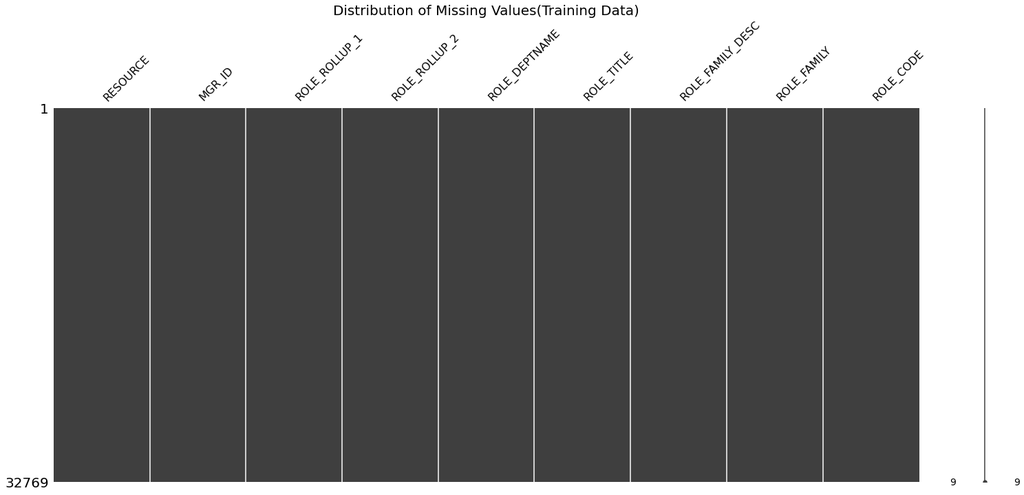

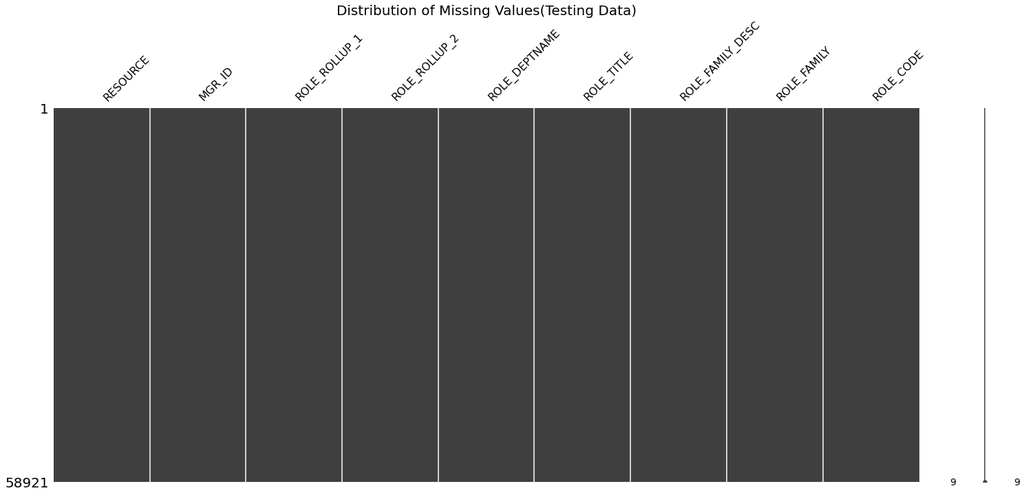

```python
data = pd.read_csv('./train.csv')
data_test = pd.read_csv('./test.csv')
Y = data['ACTION']
X = data.drop('ACTION', axis = 1)
X_test = data_test.drop('id' , axis = 1)

def missing_values_table(data):
    missing_value = data.isnull().sum()
    missing_value_percent = data.isnull().sum() / data.shape[0] * 100
    missing_value_table = pd.concat([missing_value , missing_value_percent] , axis = 1)
    missing_value_table = missing_value_table.rename(columns = {0 : 'Missing Values' , 1 : '% of Total Values'})
    missing_value_table.sort_values('% of Total Values' , ascending = False , inplace = True)
    print('There are a total of {} columns, and {} features have missing values.'.format(len(missing_value_table) , (missing_value_table['% of Total Values'] != 0).sum()))
    return missing_value_table.loc[missing_value_table['% of Total Values'] != 0]
missing_values_table(X)
missing_values_table(X_test)

msno.matrix(X).set_title('Distribution of Missing Values(Training Data)', fontsize = 20)
msno.matrix(X_test).set_title('Distribution of Missing Values(Testing Data)', fontsize = 20)
X_ = X.astype(str)
X_.info()
```

```python
label_percentage = pd.DataFrame(Y.value_counts())
label_percentage['ACTION'] = label_percentage['ACTION'] / label_percentage['ACTION'].sum() * 100
fig = px.bar(x = label_percentage.index ,
             y = label_percentage['ACTION'],
             text = np.round(label_percentage['ACTION'] , 2),
             color = pd.Series(label_percentage.index).astype(str),
             color_discrete_sequence = px.colors.sequential.RdBu ,
             template = 'plotly',
             title = 'Label Percentage')

fig.update_traces(width = 0.7 , marker = dict(line = dict(color = '#000000' , width = 2)))
fig.update_layout(xaxis_title = 'Label',
                  yaxis_title = 'Percentage',
                  font = dict(size=17 , family = 'Franklin Gothic'))
fig.show()
```

[interactive chart not shown]

#### The plot suggests an imbalanced dataset, where most requests are approved and only a few are rejected. To address this, techniques like upsampling or downsampling may be needed before building the model.

## 2.2. Compute the Relationship Between Two Features

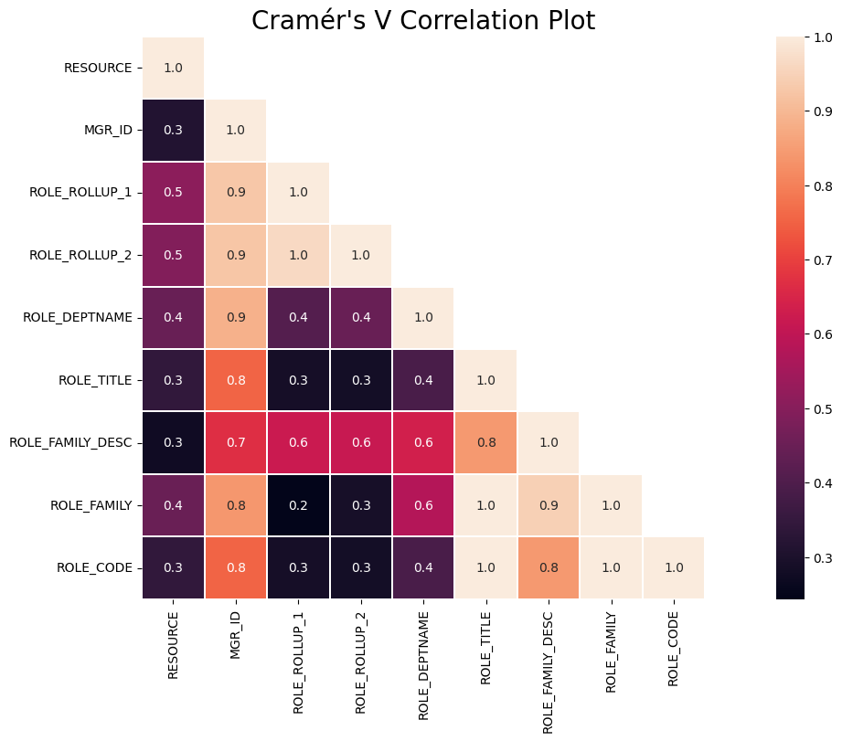

```python
X_total = pd.concat([X , X_test] , axis = 0)

def cramers_v(x, y):
    confusion_matrix = pd.crosstab(x, y)
    chi2 = stats.chi2_contingency(confusion_matrix)[0]
    n = confusion_matrix.values.sum()
    phi2 = chi2 / n
    r, k = confusion_matrix.shape
    return np.sqrt(phi2 / (min(k-1 , r-1)))

cols =list(X_total.columns)
matrix = pd.DataFrame(np.zeros((len(cols) , len(cols))) , index = cols , columns = cols)

for col1 in cols:
    for col2 in cols:
        matrix.loc[col1, col2]  = cramers_v(X_total[col1],  X_total[col2])

mask = np.array(matrix)
mask[np.tril_indices_from(mask)] = False

fig , ax = plt.subplots()
fig.set_size_inches(20 , 8)
sns.heatmap(matrix,
            mask = mask,
            square = True,
            annot = True,
            fmt = '.1f',
            linewidth = .3).set_title("""Cramér's V Correlation Plot""" , fontsize = 20)
```

```python
dimensions = [dict(label = col , values = X_total[col]) for col in X_total.columns]
fig = go.Figure(data = go.Splom(dimensions = dimensions ,
                                showupperhalf = False ,
                                marker = dict(showscale = False ,
                                              line_color = 'black',
                                              line_width = 0.5)))

fig.update_layout(title = 'Feature Pair Plit',
                  dragmode = 'select',
                  width = 1000 ,
                  height = 1000 ,
                  font = dict(size = 7 , family = 'Franklin Gothic') ,
                  hovermode = 'closest')

fig.show()

# Drop ROLE_CODE
X = X.drop('ROLE_CODE', axis = 1)
X_test = X_test.drop('ROLE_CODE' , axis = 1)
```

[interactive chart not shown]

#### The pair plot clearly shows a perfect diagonal alignment between ROLE_TITLE and ROLE_CODE, indicating a one-to-one correspondence. This visual pattern is consistent with the Cramér’s V value of 1.0, confirming a strong deterministic relationship between the two variables.

## 2.3. Check Consistency of Training and Test Set Distributions

```python
X_len = len(X)
X_total = pd.concat([X , X_test] , axis = 0)
X_total = X_total.reset_index(drop = True)
X_total = X_total.astype(str)
```

```python
for col in X_total.columns:
    diff_part = set(list(X_test[col])).difference(set(list(X[col])))
    train_data_part = set(list(X[col]))
    print('{} : {:.2%} of the categories in the testing set are not found in the training set.'.format(col , len(diff_part)/len(train_data_part)))
```

```
RESOURCE : 0.00% of the categories in the testing set are not found in the training set.
MGR_ID : 15.79% of the categories in the testing set are not found in the training set.
ROLE_ROLLUP_1 : 1.56% of the categories in the testing set are not found in the training set.
ROLE_ROLLUP_2 : 3.39% of the categories in the testing set are not found in the training set.
ROLE_DEPTNAME : 6.01% of the categories in the testing set are not found in the training set.
ROLE_TITLE : 5.25% of the categories in the testing set are not found in the training set.
ROLE_FAMILY_DESC : 25.15% of the categories in the testing set are not found in the training set.
ROLE_FAMILY : 1.49% of the categories in the testing set are not found in the training set.
```

#### "MGR_ID", "ROLE_FAMILY_DESC" have categories of high proportion in the testing set not found in the training set. We may find a way to align the data distributions to ensure they are consistent, as inconsistency can impact modeling performance.

**The infrequently occurring categories can be grouped together as one category.**

```python
def filter_func(x , condition):
    if x in condition:
        return 999999999
    else:
        return x

for col in X_total.columns:
    count =  X_total[col].value_counts()
    condition = list(count.loc[count <= 3].index)
    X_total[col] = X_total[col].apply(lambda x : filter_func(x , condition))
```

```python
X = X_total.iloc[:X_len , :]
X_test = X_total.iloc[X_len: , :]

for col in X_total.columns:
    diff_part = set(list(X_test[col])).difference(set(list(X[col])))
    train_data_part = set(list(X[col]))
    print('{} : {:.2%} of the categories in the test set are not found in the training set.'.format(col , len(diff_part)/len(train_data_part)))
```

```
RESOURCE : 0.00% of the categories in the test set are not found in the training set.
MGR_ID : 3.68% of the categories in the test set are not found in the training set.
ROLE_ROLLUP_1 : 0.00% of the categories in the test set are not found in the training set.
ROLE_ROLLUP_2 : 0.00% of the categories in the test set are not found in the training set.
ROLE_DEPTNAME : 1.40% of the categories in the test set are not found in the training set.
ROLE_TITLE : 0.31% of the categories in the test set are not found in the training set.
ROLE_FAMILY_DESC : 4.18% of the categories in the test set are not found in the training set.
ROLE_FAMILY : 1.49% of the categories in the test set are not found in the training set.
```

There has been a significant reduction in the instances of inconsistency.

## 2.4. Generating New Feature

As the features are randomly encoded and nominal in nature, arithmetic operations like addition or subtraction wouldn't provide substantial improvements. However, we can explore the possibility of concatenating these features together.

combination_num = **n** : using **hashing to combine n features** and create a new feature.

- ex : combination_num = 2
  - idx =

    - ```
         (0, 1) (0, 2) (0, 3) (0, 4) (0, 5) (0, 6) (0, 7)
      ```

    - ```
                (1, 2) (1, 3) (1, 4) (1, 5) (1, 6) (1, 7)
      ```

    - ```
                       (2, 3) (2, 4) (2, 5) (2, 6) (2, 7)
      ```

    - ```
                              (3, 4) (3, 5) (3, 6) (3, 7)
      ```

    - ```
                                     (4, 5) (4, 6) (4, 7)
      ```

    - ```
                                            (5, 6) (5, 7)
      ```

    - ```
                                                   (6, 7)
      ```

```python
def concat_features_combination(df , cols , combination_num = 2):
    combine_features = []
    for idx in combinations(range(0 , len(cols)) , combination_num):
        temp = []
        for data in df[: , list(idx)]:
            temp.append(hash(tuple(data)))
        temp = pd.DataFrame(temp)
        temp = temp.rename(columns = {0 : str(idx)})
        combine_features.append(temp)
    return pd.concat(combine_features , axis = 1)

X_total_twi = concat_features_combination(np.array(X_total) , X_total.columns)
X_total_tri = concat_features_combination(np.array(X_total) , X_total.columns , combination_num = 3)
X_total_twi = X_total_twi.astype(str)
X_total_tri = X_total_tri.astype(str)

# Ordinal encoding for twi feature
enc_twi = OrdinalEncoder().fit(X_total_twi)
X_total_twi = enc_twi.transform(X_total_twi)
X_total_twi = X_total_twi.reset_index(drop = True)

# Ordinal encoding for tri feature
enc_tri = OrdinalEncoder().fit(X_total_tri)
X_total_tri = enc_tri.transform(X_total_tri)
X_total_tri = X_total_tri.reset_index(drop = True)

# concat original , twi , tri dataset
X_total_categorical = pd.concat([X_total , X_total_twi , X_total_tri] , axis = 1)
features = X_total_categorical.columns
```

## 2.5. Category Encoding

## 2.5.1. KFold Target Encoding

```python
class KFoldTargetEncoderTrain(base.BaseEstimator , base.TransformerMixin):
    def __init__(self , colnames , targetName , n_fold = 5 , verbosity = True , discardOriginal_col = False):
        self.colnames = colnames
        self.targetName = targetName
        self.n_fold = n_fold
        self.verbosity = verbosity
        self.discardOriginal_col = discardOriginal_col

    def fit(self , X , y = None):
        return self

    def transform(self , X):
        assert(type(self.targetName) == str)
        assert(type(self.colnames) == str)
        assert(self.colnames in X.columns)
        assert(self.targetName in X.columns)

        mean_of_target = X[self.targetName].mean()
        kf = KFold(n_splits = self.n_fold , shuffle = True , random_state = 2019)

        col_mean_name =  '{}_{}_{}'.format(self.colnames , self.n_fold , 'Kfold_Target')
        X[col_mean_name] = np.nan

        for tr_ind , val_ind in kf.split(X):
            X_tr , X_val = X.iloc[tr_ind], X.iloc[val_ind]
            X.loc[X.index[val_ind] , col_mean_name] = X_val[self.colnames].map(X_tr.groupby(self.colnames)[self.targetName].mean())

        X[col_mean_name].fillna(mean_of_target , inplace = True)

        if self.verbosity:
            encoded_feature = X[col_mean_name].values
            print('Correlation between the new feature, {} and, {} is {}.'.format(col_mean_name,
                                                                                  self.targetName,
                                                                                  np.corrcoef(X[self.targetName].values, encoded_feature)[0][1]))
        if self.discardOriginal_col:
            X = X.drop(self.targetName, axis=1)

        return X

class KFoldTargetEncoderTest(base.BaseEstimator, base.TransformerMixin):
    def __init__(self,train,colNames,encodedName):
        self.train = train
        self.colNames = colNames
        self.encodedName = encodedName

    def fit(self, X, y=None):
        return self

    def transform(self,X):
        mean = self.train[[self.colNames, self.encodedName]].groupby(self.colNames).mean().reset_index()
        dd = {}
        for index, row in mean.iterrows():
            dd[row[self.colNames]] = row[self.encodedName]
        X[self.encodedName] = X[self.colNames]
        X = X.replace({self.encodedName: dd})
        return X


X_total_target_enc = X_total_categorical.copy(deep = True)
features = X_total_target_enc.columns
Y_total = pd.DataFrame(np.ones(len(X_total_target_enc)))
Y_total.iloc[:X_len , 0] = Y
X_total_target_enc = X_total_target_enc.reset_index(drop = True)
X_total_target_enc = pd.concat([X_total_target_enc  , pd.DataFrame(Y_total).rename({0 : 'label'} , axis = 1)] , axis = 1)
for feature in features:
    target_encoder = KFoldTargetEncoderTrain(feature , 'label' , n_fold = 5)
    target_encoder.fit(X_total_target_enc)
    X_total_target_enc = target_encoder.transform(X_total_target_enc)

X_total_target_enc = X_total_target_enc.drop(list(features) + ['label'] , axis = 1)
```

```
Correlation between the new feature, RESOURCE_5_Kfold_Target and, label is 0.0823148642547431.
Correlation between the new feature, MGR_ID_5_Kfold_Target and, label is 0.2250278954524642.
Correlation between the new feature, ROLE_ROLLUP_1_5_Kfold_Target and, label is 0.06795436758082077.
Correlation between the new feature, ROLE_ROLLUP_2_5_Kfold_Target and, label is 0.08453415435977743.
Correlation between the new feature, ROLE_DEPTNAME_5_Kfold_Target and, label is 0.13923375096413834.
Correlation between the new feature, ROLE_TITLE_5_Kfold_Target and, label is 0.09651871525048646.
Correlation between the new feature, ROLE_FAMILY_DESC_5_Kfold_Target and, label is 0.1454111527141569.
Correlation between the new feature, ROLE_FAMILY_5_Kfold_Target and, label is 0.07005939813376397.
Correlation between the new feature, (0, 1)_5_Kfold_Target and, label is 0.11574893897693105.
Correlation between the new feature, (0, 2)_5_Kfold_Target and, label is 0.08945481687763406.
Correlation between the new feature, (0, 3)_5_Kfold_Target and, label is 0.10327990012197943.
Correlation between the new feature, (0, 4)_5_Kfold_Target and, label is 0.10418925378785274.
Correlation between the new feature, (0, 5)_5_Kfold_Target and, label is 0.061788214657021834.
Correlation between the new feature, (0, 6)_5_Kfold_Target and, label is 0.09333919727701726.
Correlation between the new feature, (0, 7)_5_Kfold_Target and, label is 0.07658374933200206.
Correlation between the new feature, (1, 2)_5_Kfold_Target and, label is 0.22514140721771986.
Correlation between the new feature, (1, 3)_5_Kfold_Target and, label is 0.2326991151355611.
Correlation between the new feature, (1, 4)_5_Kfold_Target and, label is 0.22970556993950905.
Correlation between the new feature, (1, 5)_5_Kfold_Target and, label is 0.24937457941097568.
Correlation between the new feature, (1, 6)_5_Kfold_Target and, label is 0.2500101676189511.
Correlation between the new feature, (1, 7)_5_Kfold_Target and, label is 0.23424094198316003.
Correlation between the new feature, (2, 3)_5_Kfold_Target and, label is 0.08478778149869978.
Correlation between the new feature, (2, 4)_5_Kfold_Target and, label is 0.1794776990454261.
Correlation between the new feature, (2, 5)_5_Kfold_Target and, label is 0.14610269534178477.
Correlation between the new feature, (2, 6)_5_Kfold_Target and, label is 0.17068586068240732.
Correlation between the new feature, (2, 7)_5_Kfold_Target and, label is 0.1178837805316116.
Correlation between the new feature, (3, 4)_5_Kfold_Target and, label is 0.19321640715046423.
Correlation between the new feature, (3, 5)_5_Kfold_Target and, label is 0.17862733385295196.
Correlation between the new feature, (3, 6)_5_Kfold_Target and, label is 0.19258104468306.
Correlation between the new feature, (3, 7)_5_Kfold_Target and, label is 0.1477429016872061.
Correlation between the new feature, (4, 5)_5_Kfold_Target and, label is 0.21278751114134453.
Correlation between the new feature, (4, 6)_5_Kfold_Target and, label is 0.23016705282294153.
Correlation between the new feature, (4, 7)_5_Kfold_Target and, label is 0.17900558504175962.
Correlation between the new feature, (5, 6)_5_Kfold_Target and, label is 0.1603677678133851.
Correlation between the new feature, (5, 7)_5_Kfold_Target and, label is 0.09581704091963046.
Correlation between the new feature, (6, 7)_5_Kfold_Target and, label is 0.1493812146064738.
Correlation between the new feature, (0, 1, 2)_5_Kfold_Target and, label is 0.11332049114761855.
Correlation between the new feature, (0, 1, 3)_5_Kfold_Target and, label is 0.11634111214814916.
Correlation between the new feature, (0, 1, 4)_5_Kfold_Target and, label is 0.11730521170283507.
Correlation between the new feature, (0, 1, 5)_5_Kfold_Target and, label is 0.12007799625017455.
```

[output cut: 31 more lines]

```
Correlation between the new feature, (1, 6, 7)_5_Kfold_Target and, label is 0.2508029364402449.
Correlation between the new feature, (2, 3, 4)_5_Kfold_Target and, label is 0.19262700172076383.
Correlation between the new feature, (2, 3, 5)_5_Kfold_Target and, label is 0.17721211491142658.
Correlation between the new feature, (2, 3, 6)_5_Kfold_Target and, label is 0.1915477637386253.
Correlation between the new feature, (2, 3, 7)_5_Kfold_Target and, label is 0.1464934635785995.
Correlation between the new feature, (2, 4, 5)_5_Kfold_Target and, label is 0.230790855630149.
Correlation between the new feature, (2, 4, 6)_5_Kfold_Target and, label is 0.23749477536705593.
Correlation between the new feature, (2, 4, 7)_5_Kfold_Target and, label is 0.20685614904573338.
Correlation between the new feature, (2, 5, 6)_5_Kfold_Target and, label is 0.18163582434709938.
Correlation between the new feature, (2, 5, 7)_5_Kfold_Target and, label is 0.14615848529898468.
Correlation between the new feature, (2, 6, 7)_5_Kfold_Target and, label is 0.17260721382053046.
Correlation between the new feature, (3, 4, 5)_5_Kfold_Target and, label is 0.23588785558146852.
Correlation between the new feature, (3, 4, 6)_5_Kfold_Target and, label is 0.24298596582797227.
Correlation between the new feature, (3, 4, 7)_5_Kfold_Target and, label is 0.21567360987082237.
Correlation between the new feature, (3, 5, 6)_5_Kfold_Target and, label is 0.2075801892846929.
```

```
Correlation between the new feature, (3, 5, 7)_5_Kfold_Target and, label is 0.17874409016827053.
Correlation between the new feature, (3, 6, 7)_5_Kfold_Target and, label is 0.1934926897277154.
Correlation between the new feature, (4, 5, 6)_5_Kfold_Target and, label is 0.2467152928518916.
Correlation between the new feature, (4, 5, 7)_5_Kfold_Target and, label is 0.21278326378450932.
Correlation between the new feature, (4, 6, 7)_5_Kfold_Target and, label is 0.23262818430434898.
Correlation between the new feature, (5, 6, 7)_5_Kfold_Target and, label is 0.1602983709891469.
```

## 2.5.2. Count Encoding

```python
def category_freq(X):
    X_new = X.copy()
    for f in X_new.columns:
        count_data = X_new[f].value_counts().reset_index()
        count_data = count_data.rename(columns = {'index' : f , f : '{}_count'.format(f)})
        X_new = pd.merge(left = X_new , right = count_data , on = f , how ='left')
    return X_new

X_total_freq = category_freq(X_total_categorical)
X_total_freq = X_total_freq.drop(list(features) , axis = 1)
```

```python
X_train_num = np.concatenate([X_total_freq , X_total_target_enc] , axis = 1)[:X_len , :]
X_test_num = np.concatenate([X_total_freq , X_total_target_enc] , axis = 1)[X_len: , :]
X_train_num = pd.DataFrame(X_train_num)
X_test_num = pd.DataFrame(X_test_num)
```

# 3. Modeling

## 3.1. Base Model

```python
def cv_score(model , X , Y):
    kf = StratifiedKFold(n_splits = 5 , shuffle = True , random_state = 10)
    mean_auc = []
    for train_index , test_index in kf.split(X , Y):
        X_train = X.iloc[train_index , :]
        y_train = Y.iloc[train_index]
        X_test = X.iloc[test_index , :]
        y_test = Y.iloc[test_index]

        model.fit(X_train , y_train)
        preds = model.predict_proba(X_test)[: , 1]
        AUC = roc_auc_score(y_test , preds)
        mean_auc.append(AUC)
    print('AUC Score from model: {}'.format(np.mean(mean_auc)))


rf_base_model = RandomForestClassifier(n_estimators = 400,
                                       min_samples_split = 10,
                                       min_samples_leaf = 2,
                                       max_features = 'auto',
                                       max_depth = 20,
                                       bootstrap = False,
                                       n_jobs = -1 ,
                                       class_weight = 'balanced')

ex_base_model = ExtraTreesClassifier(n_estimators = 400,
                                     min_samples_split = 10,
                                     min_samples_leaf = 2,
                                     max_features = 'auto',
                                     max_depth = 20,
                                     bootstrap = False,
                                     n_jobs = -1 ,
                                     class_weight = 'balanced')

lgb_base_model = LGBMClassifier(n_jobs = -1)

xgb_base_model = XGBClassifier(base_score=0.5, booster='gbtree', callbacks=None,
                               colsample_bylevel=1, colsample_bynode=1, colsample_bytree=0.5,
                               early_stopping_rounds=None, enable_categorical=False,
                               eval_metric=None, gamma=0.3, gpu_id=-1, grow_policy='depthwise',
                               importance_type=None, interaction_constraints='',
                               learning_rate=0.1, max_bin=256, max_cat_to_onehot=4,
                               max_delta_step=0, max_depth=15, max_leaves=0, min_child_weight=1, monotone_constraints='()', n_estimators=100,
                               n_jobs=0, num_parallel_tree=1, predictor='auto', random_state=0,
                               reg_alpha=0, reg_lambda=1)

cat_base_model = CatBoostClassifier(class_weights = [20 , 1] , verbose = False)


cv_score(rf_base_model , X_train_num , Y)
cv_score(ex_base_model , X_train_num , Y)
cv_score(lgb_base_model , X_train_num , Y)
cv_score(xgb_base_model , X_train_num , Y)
cv_score(cat_base_model , X_train_num , Y)
```

```
AUC Score from model: 0.910357390065173
AUC Score from model: 0.9045941435407567
AUC Score from model: 0.9024192766450602
AUC Score from model: 0.9072390382146297
AUC Score from model: 0.9020717877478546
```

## 3.2. Model Fine-Tuning

## 3.2.1. RandomForestClassifier

```python
# def objective_cv_rf(trial , X = X_train_num , y = Y):
#     global RANDOM_STATE
#     print(RANDOM_STATE)
#     param = {'bootstrap'          : trial.suggest_categorical('bootstrap' , [True, False]) ,
#              'max_features'       : trial.suggest_categorical('max_features' , ['auto' , 'sqrt']) ,
#              'criterion'          : trial.suggest_categorical('criterion' , ['gini' , 'entropy']) ,
#              'n_estimators'       : trial.suggest_int('n_estimators' , 100 , 1000) ,
#              'max_depth'          : trial.suggest_int('max_depth' , 5 , 100) ,
#              'min_samples_split'  : trial.suggest_int('min_samples_split' , 2 , 20),
#              'min_samples_leaf'   : trial.suggest_int('min_samples_leaf' , 1 , 10)}

#     kf = StratifiedKFold(n_splits = 5 , shuffle = True , random_state = 42)
#     cv_scores = []
#     for idx , (train_idx , test_idx) in enumerate(kf.split(X , y)):
#         X_train , X_test = X.iloc[train_idx] , X.iloc[test_idx]
#         y_train , y_test = y.iloc[train_idx] , y.iloc[test_idx]
#         model = RandomForestClassifier(class_weight = 'balanced' , n_jobs = -1 , **param)
#         model.fit(X_train , y_train)
#         preds = model.predict_proba(X_test)[: , 1]
#         AUC = roc_auc_score(y_test , preds)
#         cv_scores.append(AUC)
#     return -np.mean(cv_scores)

# rf_params_set = []
# for i in range(0 , 3):
#     RANDOM_STATE = 42 + i
#     study = optuna.create_study(direction = 'minimize')
#     study.optimize(objective_cv_rf , n_trials = 100)
#     print('Number of finished trials:{}'.format(len(study.trials)))
#     rf_result = study.trials_dataframe()
#     rf_params = study.best_params
#     rf_params_set.append(rf_params)
#     print('rf_{} completed !!'.format(i + 1))
```

## 3.2.2. ExtraTreesClassifier

```python
# def objective_cv_ex(trial , X = X_train_num , y = Y):
#     param = {'bootstrap'          : trial.suggest_categorical('bootstrap' , [True, False]) ,
#              'max_features'       : trial.suggest_categorical('max_features' , ['auto' , 'sqrt']) ,
#              'criterion'          : trial.suggest_categorical('criterion' , ['gini' , 'entropy']) ,
#              'n_estimators'       : trial.suggest_int('n_estimators' , 100 , 1000) ,
#              'max_depth'          : trial.suggest_int('max_depth' , 5 , 100) ,
#              'min_samples_split'  : trial.suggest_int('min_samples_split' , 2 , 20),
#              'min_samples_leaf'   : trial.suggest_int('min_samples_leaf' , 1 , 10)}

#     kf = StratifiedKFold(n_splits = 5 , shuffle = True , random_state = 42)
#     cv_scores = []
#     for idx , (train_idx , test_idx) in enumerate(kf.split(X , y)):
#         X_train , X_test = X.iloc[train_idx] , X.iloc[test_idx]
#         y_train , y_test = y.iloc[train_idx] , y.iloc[test_idx]
#         model = ExtraTreesClassifier(class_weight = 'balanced' , n_jobs = -1 , **param)
#         model.fit(X_train , y_train)
#         preds = model.predict_proba(X_test)[: , 1]
#         AUC = roc_auc_score(y_test , preds)
#         cv_scores.append(AUC)
#     return -np.mean(cv_scores)

# ex_params_set = []
# for i in range(0 , 3):
#     RANDOM_STATE = 42 + i
#     study = optuna.create_study(direction = 'minimize')
#     study.optimize(objective_cv_ex , n_trials = 100)
#     print('Number of finished trials:{}'.format(len(study.trials)))
#     ex_result = study.trials_dataframe()
#     ex_params = study.best_params
#     ex_params_set.append(ex_params)
#     print('ex_{} completed !!'.format(i + 1))
```

## 3.2.3. LGBMClassifier

```python
# def objective_cv_lgb(trial , X = X_train_num , y = Y):
#     param = {'learning_rate'      : trial.suggest_loguniform('learning_rate' , 0.006 , 0.02),
#              'reg_alpha'          : trial.suggest_loguniform('reg_alpha' , 1e-9 , 10.0) ,  # L1 regularization
#              'reg_lambda'         : trial.suggest_loguniform('reg_lambda' , 1e-9 , 10.0) , # L2 regularization
#              'colsample_bytree'   : trial.suggest_categorical('colsample_bytree' , [i/10 for i in range(3 , 11)]) ,  #  deal with over-fitting
#              'subsample'          : trial.suggest_categorical('subsample' , [i/10 for i in range(4 , 11)]) ,         #  deal with over-fitting
#              'n_estimators'       : trial.suggest_int('n_estimators' , 100 , 20000) ,
#              'max_depth'          : trial.suggest_int('max_depth' , 5 , 100),
#              'num_leaves'         : trial.suggest_int('num_leaves' , 5 , 1000),
#              'min_child_samples'  : trial.suggest_int('min_child_samples' , 1 , 300),     #  deal with over-fitting
#              'min_child_weight'   : trial.suggest_int('min_child_samples' , 0.01 , 10),   #  deal with over-fitting
#              'cat_smooth'         : trial.suggest_int('cat_smooth' , 1 , 100)}

#     kf = StratifiedKFold(n_splits = 5 , shuffle = True , random_state = 42)
#     cv_scores = []
#     for idx , (train_idx , test_idx) in enumerate(kf.split(X , y)):
#         X_train , X_test = X.iloc[train_idx] , X.iloc[test_idx]
#         y_train , y_test = y.iloc[train_idx] , y.iloc[test_idx]
#         model = LGBMClassifier(objective = 'binary' , metric = 'auc' , class_weight = 'balanced' , **param)
#         model.fit(X_train , y_train , eval_set = [(X_test , y_test)] , early_stopping_rounds = 500 , verbose = False)
#         preds = model.predict_proba(X_test)[: , 1]
#         AUC = roc_auc_score(y_test , preds)
#         cv_scores.append(AUC)
#     return -np.mean(cv_scores)

# lgb_params_set = []
# for i in range(0 , 3):
#     RANDOM_STATE = 42 + i
#     study = optuna.create_study(direction = 'minimize')
#     study.optimize(objective_cv_lgb , n_trials = 100)
#     print('Number of finished trials:{}'.format(len(study.trials)))
#     lgb_result = study.trials_dataframe()
#     lgb_params = study.best_params
#     lgb_params_set.append(lgb_params)
```

## 3.2.4. XGBClassifier

```python
# def objective_cv_xgb(trial , X = X_train_num , y = Y):
#     param = {'scale_pos_weight'   : trial.suggest_uniform('scale_pos_weight' , 1/20 , 1/16) ,
#              'learning_rate'      : trial.suggest_loguniform('learning_rate' , 0.006 , 0.02),
#              'lambda'             : trial.suggest_loguniform('lambda' , 1e-3 , 10.0),
#              'alpha'              : trial.suggest_loguniform('alpha' , 1e-3 , 10.0),
#              'reg_alpha'          : trial.suggest_loguniform('reg_alpha' , 1e-3 , 10.0) ,
#              'reg_lambda'         : trial.suggest_loguniform('reg_lambda' , 1e-3 , 10.0) ,
#              'colsample_bytree'   : trial.suggest_categorical('colsample_bytree' , [i/10 for i in range(3 , 11)]) ,
#              'subsample'          : trial.suggest_categorical('subsample' , [i/10 for i in range(4 , 11)]) ,
#              'n_estimators'       : trial.suggest_int('n_estimators' , 100 , 20000) ,
#              'max_depth'          : trial.suggest_int('max_depth' , 10 , 100),
#              'max_leaves'         : trial.suggest_int('max_leaves' , 10 , 1000),
#              'min_child_weight'   : trial.suggest_int('min_child_weight', 1 , 300)}

#     kf = StratifiedKFold(n_splits = 5 , shuffle = True , random_state = 42)
#     cv_scores = []
#     for idx , (train_idx , test_idx) in enumerate(kf.split(X , y)):
#         X_train , X_test = X.iloc[train_idx] , X.iloc[test_idx]
#         y_train , y_test = y.iloc[train_idx] , y.iloc[test_idx]
#         model = XGBClassifier(objective = 'binary:logistic' , eval_metric = 'auc' , **param)
#         model.fit(X_train , y_train , eval_set = [(X_test , y_test)] , early_stopping_rounds = 500 , verbose = False)
#         preds = model.predict(X_test)
#         AUC = roc_auc_score(y_test , preds)
#         cv_scores.append(AUC)
#     return -np.mean(cv_scores)

# xgb_params_set = []
# for i in range(0 , 3):
#     RANDOM_STATE = 42 + i
#     study = optuna.create_study(direction = 'minimize')
#     study.optimize(objective_cv_xgb , n_trials = 100)
#     print('Number of finished trials:{}'.format(len(study.trials)))
#     xgb_result = study.trials_dataframe()
#     xgb_params = study.best_params
#     xgb_params['objective'] = 'binary:logistic'
#     xgb_params['eval_metric'] = 'auc'
#     xgb_params_set.append(xgb_params)
```

## 3.2.5. CatBoostClassifier

```python
# def objective_cv_cat(trial ,X = X_train_num , y = Y):
#     param = {'l2_leaf_reg'       : trial.suggest_loguniform('l2_leaf_reg' , 1e-3 , 10.0),
# #             'rsm'               : trial.suggest_uniform('rsm' , 0.3 , 1.0),
#              'subsample'         : trial.suggest_uniform('subsample' , 0.4 , 1.0),
#              'learning_rate'     : trial.suggest_uniform('learning_rate' , 0.006 , 0.018),
#              'n_estimators'       : trial.suggest_int('n_estimators' , 100 , 20000) ,
#              'max_depth'         : trial.suggest_int('max_depth' , 5 , 15),
#              'max_bin'           : trial.suggest_int('max_bin' , 200 , 400),
#              'min_data_in_leaf'  : trial.suggest_int('min_data_in_leaf' , 1 , 300) ,
#              'class_weights'     : [trial.suggest_int('class_weights' , 16 , 20) , 1]}

#     kf = StratifiedKFold(n_splits = 5 , shuffle = True , random_state = 42)
#     cv_scores = []
#     for idx , (train_idx , test_idx) in enumerate(kf.split(X , y)):
#         X_train , X_test = X.iloc[train_idx] , X.iloc[test_idx]
#         y_train , y_test = y.iloc[train_idx] , y.iloc[test_idx]
#         model = CatBoostClassifier(loss_function = 'logloss' , eval_metric = 'AUC' , **param)
#         model.fit(X_train , y_train , eval_set = [(X_test , y_test)] , early_stopping_rounds = 500 , verbose = False)
#         preds = model.predict(X_test)
#         AUC = roc_auc_score(y_test , preds)
#         cv_scores.append(AUC)
#     return -np.mean(cv_scores)

# cat_params_set = []
# for i in range(0 , 3):
#     RANDOM_STATE = 42 + i
#     study = optuna.create_study(direction = 'minimize')
#     study.optimize(objective_cv_cat , n_trials = 100)
#     print('Number of finished trials:{}'.format(len(study.trials)))
#     cat_results = study.trials_dataframe()
#     cat_params = study.best_params
#     cat_params_set.append(cat_params)
```